# Analyse : Concevez une application au service de la santé publique

[figure not shown]

# Projet-3 : Analyse des données

```python
import pandas as pd
import numpy as np
import datetime as dt
import sys
import warnings
import IPython as ip
import matplotlib.pyplot as plt
import seaborn as sns
from IPython.display import display
import missingno as msno
# Configuration pour travail avec fichier python "tools" de fonctions
%load_ext autoreload
%aimport tools
# Recharger les modules pour la conception des fichiers tools
%autoreload 1

# Set option
pd.set_option('display.max_columns', None)
pd.set_option('display.max_rows', None)

warnings.filterwarnings("ignore")
```

# IDEE APPLICATION

- L'application doit permettre aux personnes qui recherchent des conseils alimentaires en cas de maladie rénale chronique de trouver des informations suppleméntaires (info visuel) qui est spécifique au gens qui doivent préserver au mieux leurs reins (problème rénal).
- L'application ne remplace pas un régime spécifique fait par un professionnel de santé mais constitue une aide à a décision par une information simplifiée concernant les indicateur qui sont importants de surveiller lorsqu'on doit surveiller son alimentation pour préserver ses reins.
- Objectifs : COMMENT PROTEGER MES REINS ?
  - Limiter l’apport en sel
  - Contrôler les apports en protéines,
  - Couvrir les besoins nutritionnels,
  - Conserver le plaisir de manger.

On surveille :

- Le poids : alimentation saine, équilibrée et plaisir :
  - 'nutrition-score-fr_100g','energy_100g'
  - 'fat_100g', 'saturated-fat_100g','carbohydrates_100g', 'sugars_100g', 'fiber_100g'
- Les indicateurs disponibles :
  - **Sel('salt_100g')**
  - **Sodium('sodium_100g')** : sel minéral qui intervient dans l’équilibre hydrique du corps
    - 1g de sel (NaCl) équivaut à 400 mg de sodium (Na)
    - 1 gramme de sodium(Na) correspond donc à 2.5 g de sel
  - **Proteines ('proteins_100g')** : Au stade d’insuffisance rénale les besoins en protéines sont de 0,8g/Kg/j
    - en fonction du poids :
      - -60kg => 40g
      - 60kg => 46g
      - 70kg => 56g
      - 80kg => 64g
  - Le potassium est un minéral important présent dans un grand nombre d’aliments indispensables au bon fonctionnement des muscles et du coeur. : trop de données manquantes
  - **Le phosphore est surtout présent dans les aliments, lié aux protéines.**
    - La limitation protéique entraîne déjà une diminution des apports en phosphore.
  - Limiter les additifs :
    - E 338 Acide phosphorique (boisson au cola)
    - E 339 Phosphates de sodium
    - E 340 Phosphates de potassium
    - E 341 Phosphates de calcium
    - E 343 Phosphates de magnésium
    - E 450 Diphosphates
    - E 451 Triphosphates
    - E 452 Polyphosphates

# 1. Chargement du jeu de données (dataset en anglais)

```python
# Import données
data = pd.read_csv('assets/datas/df_application.csv', sep='\t', low_memory=False)
```

```python
df = data.copy()
```

```python
# Visualisation d'un échantillon de la population
df.sample(5)
```

|  | code | creator | created_datetime | last_modified_datetime | product_name | brands | categories_fr | countries_fr | additives_n | ingredients_from_palm_oil_n | nutrition_grade_fr | main_category_fr | energy_100g | fat_100g | saturated-fat_100g | carbohydrates_100g | sugars_100g | fiber_100g | proteins_100g | salt_100g | sodium_100g | nutrition-score-fr_100g |
| --- | --- | --- | --- | --- | --- | --- | --- | --- | --- | --- | --- | --- | --- | --- | --- | --- | --- | --- | --- | --- | --- | --- |
| 102189 | 0610696541451 | usda-ndb-import | 2017-03-09 16:32:28 | 2017-03-09 16:32:28 | Picnic, Herbed Goat Cheese Spread | M & P Plastics Inc. | inconnu | États-Unis | 1.0 | 0.0 | d | inconnu | 1142.0 | 21.21 | 13.64 | 6.06 | 3.03 | 0.0 | 9.09 | 0.61468 | 0.242000 | 15.0 |
| 239714 | 9300605042810 | foodorigins | 2015-08-21 06:09:32 | 2015-10-16 06:06:37 | Strawberries & Cream | Allens,Nestle | Snacks sucrés,Confiseries | Australie | 2.0 | 0.0 | d | Snacks sucrés | 1480.0 | 0.10 | 0.10 | 82.00 | 48.00 | 0.0 | 3.70 | 0.25400 | 0.100000 | 15.0 |
| 26665 | 0035826081612 | usda-ndb-import | 2017-03-09 16:55:04 | 2017-03-09 16:55:04 | Natural Colby Jack Cheese | Food Lion | inconnu | États-Unis | 1.0 | 0.0 | e | inconnu | 1644.0 | 32.14 | 21.43 | 3.57 | 0.00 | 0.0 | 21.43 | 1.81356 | 0.714000 | 21.0 |
| 192038 | 3492390009935 | openfood-ch-import | 2017-02-07 19:33:34 | 2017-02-16 14:38:18 | Rhapsodie de fruit Framboises & Grenades | ST. DALFOUR | inconnu | Suisse | 0.0 | 0.0 | d | inconnu | 969.0 | 0.80 | 0.01 | 56.00 | 52.70 | 0.0 | 0.50 | 0.02000 | 0.007874 | 12.0 |
| 87729 | 0080000516947 | usda-ndb-import | 2017-03-09 13:54:23 | 2017-03-09 13:54:23 | Charlie's Lunch Kit, Chunk White Albacore Tuna... | Starkist | inconnu | États-Unis | 14.0 | 0.0 | b | inconnu | 690.0 | 4.96 | 1.65 | 13.22 | 3.72 | 1.2 | 14.88 | 1.00838 | 0.397000 | 1.0 |

```python
df["last_modified_datetime"] =  pd.to_datetime(df["last_modified_datetime"])
df["created_datetime"] =  pd.to_datetime(df["created_datetime"])
```

```python
df.describe()
```

|  | additives_n | ingredients_from_palm_oil_n | energy_100g | fat_100g | saturated-fat_100g | carbohydrates_100g | sugars_100g | fiber_100g | proteins_100g | salt_100g | sodium_100g | nutrition-score-fr_100g |
| --- | --- | --- | --- | --- | --- | --- | --- | --- | --- | --- | --- | --- |
| count | 240304.000000 | 240304.000000 | 240304.000000 | 240304.000000 | 240304.000000 | 240304.000000 | 240304.000000 | 240304.000000 | 240304.000000 | 240304.000000 | 240304.000000 | 240304.000000 |
| mean | 1.787436 | 0.017582 | 1115.318528 | 11.641039 | 4.455163 | 29.728607 | 14.816161 | 2.185979 | 7.046625 | 1.559819 | 0.614101 | 7.729085 |
| std | 2.464454 | 0.133063 | 789.775370 | 16.780741 | 7.504304 | 29.271999 | 20.702098 | 4.218316 | 8.120267 | 6.180167 | 2.433128 | 8.957818 |
| min | 0.000000 | 0.000000 | 0.000000 | 0.000000 | 0.000000 | 0.000000 | 0.000000 | 0.000000 | 0.000000 | 0.000000 | 0.000000 | -15.000000 |
| 25% | 0.000000 | 0.000000 | 372.000000 | 0.000000 | 0.000000 | 3.570000 | 0.640000 | 0.000000 | 0.600000 | 0.045720 | 0.018000 | 0.000000 |
| 50% | 1.000000 | 0.000000 | 1092.000000 | 3.570000 | 1.000000 | 17.000000 | 4.600000 | 0.120000 | 4.760000 | 0.543000 | 0.213780 | 6.000000 |
| 75% | 3.000000 | 0.000000 | 1674.000000 | 18.520000 | 6.250000 | 56.670000 | 21.600000 | 3.000000 | 10.000000 | 1.353820 | 0.533000 | 15.000000 |
| max | 31.000000 | 2.000000 | 3776.000000 | 100.000000 | 100.000000 | 100.000000 | 100.000000 | 100.000000 | 100.000000 | 100.000000 | 39.370079 | 40.000000 |

## Les pays

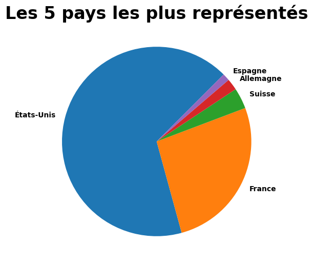

```python
# Visualiser les 5 pays les plkus représentés
country = df.groupby(by='countries_fr')['code'].nunique().sort_values(ascending=False)
n=5
fig, ax = plt.subplots(figsize=(6, 6), subplot_kw=dict(aspect="equal"))
explodes = np.zeros(n)
explodes[0] = .1
plt.pie(country[:n], labels=country[:n].index,
        startangle=45,
        textprops=dict(color="black",size=10,
                       weight="bold"))
plt.title("Les {:d} pays les plus représentés".format(n), fontweight='bold',fontsize=24)
plt.show()
```

- Les USA, la France sont les pays qui apparaiisent le plus : Une mlajorité qui peut s'expliquer par la puissances des entreprises agroallimentaires dans le monde ou zone géographique :
  - USA : 1ère puissance agricole modiale
  - France : première puissance européenne

## Qui sont les sources de ces données ?

```python
# Nombre de créateurs, sources des données
print(f"Nombre de sources unique : {df['creator'].nunique()}")
```

```
Nombre de sources unique : 2478
```

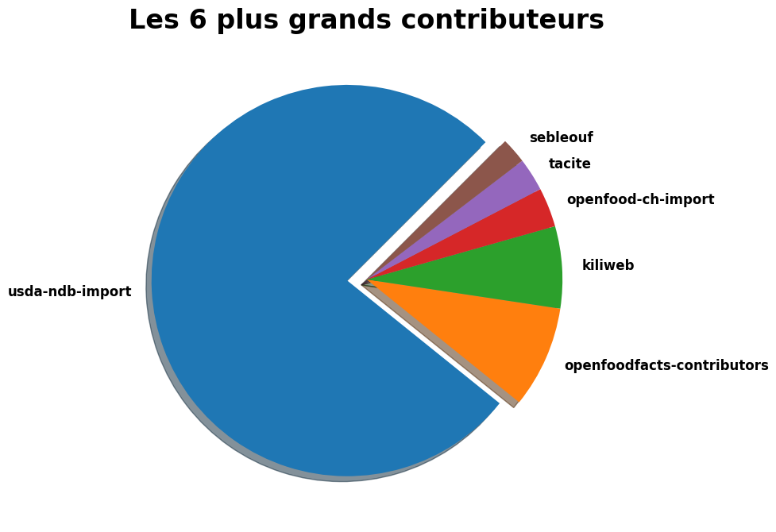

```python
creators = df.groupby(by='creator')['code'].nunique().sort_values(ascending=False)
# Graphiques des 6 plus ganrd contributeur
n= 6
fig, ax = plt.subplots(figsize=(8, 8), subplot_kw=dict(aspect="equal"))

explodes = np.zeros(n)
explodes[0] = .1

plt.pie(creators[:n], labels=creators[:n].index,
        startangle=45,
        shadow=True,
        explode=explodes,
        textprops=dict(color="black",size=12, weight="bold"))
plt.title("Les {:d} plus grands contributeurs".format(n),
          fontweight='bold',fontsize=24)

plt.show()
```